# Laptop’s price

Roger Monclús

2022-05-09

# 1 Introduction

In this project I want to study laptop’s specifications and features, and its relation to the final price.

These features are mostly hardware, per instance, storage, RAM and graphic card. Also, some other attributes in the data are the brand and a few binary variables that explain if the laptop includes some software (MS office), warranty or if it has a touchscreen.

I want to know which variables condition price the most and by how much. I will try to fit a linear model for the price, because of the interpretability of the coefficients.

After learning which features matter the most for the laptop’s price, I will create a model that fits better the data than a linear model to predict the price of a laptopt. I will use some machine learning algorithms: K-Nearest Neighbors, Random Forest and Support Vector Machine.

The dataset contains other numerical variables like star rating, number of ratings and reviews, discount and older price. Since all this attributes are obtained after the laptop has been sold in the first place, they can’t be used to predict its price. I’m doing another project studying star ratings of laptops based on these same features and also considering the price and the discount.

**Source:** I downloaded the data from kaggle.com on 04/05/2020. New versions are available in:

https://www.kaggle.com/datasets/kuchhbhi/latest-laptop-price-list

The information in this data set was pulled from Flipkart, so the prices are in Indian rupees.

I converted all prices from rupees to Euros using a 1 to 0.012 ratio (exchange rate on 04/05/2020).

**Packages**

```r
if(!require('tidyverse')) install.packages('tidyverse'); library('tidyverse')
if(!require('MASS')) install.packages('MASS'); library('MASS') # glm, LDA...
if(!require('caret')) install.packages('caret'); library('caret') # Datapartition, train...
if(!require('randomForest')) install.packages('randomForest'); library('randomForest') # Random Forest
if(!require('glmnet')) install.packages('glmnet'); library('glmnet') # Ridge & lasso regression
if(!require('FactoMineR')) install.packages('FactoMineR'); library('FactoMineR') # MCA
if(!require('factoextra')) install.packages('factoextra'); library('factoextra') # MCA plots fviz
```

# 2 Importing and cleaning data

```r
path = 'Cleaned_Laptop_price.csv'
laptops <- read.csv("C:/Users/Roger/Les Meves Coses/Estudis/Machine Learning/Cleaned_Laptop_data.csv", row.names=NULL) #path
```

```r
df <- laptops %>%
  dplyr::select(latest_price, brand, hdd, ssd, warranty, # 1 numeric
          graphic_card_gb, ram_gb, processor_brand, weight,                 # 6 nominal
          msoffice, Touchscreen)

names(df)[names(df)=="Touchscreen"] <- "touchscreen"
head(df)
```

```
##   latest_price  brand  hdd ssd warranty graphic_card_gb ram_gb processor_brand
## 1        23990   ASUS 1024   0        1               0      4           Intel
## 2        37990   ASUS    0 512        1               0      8           Intel
## 3        32890   ASUS 1024   0        1               0      8           Intel
## 4        42990     HP    0 512        1               0      8           Intel
## 5        54990     HP    0 512        0               0      8           Intel
## 6        35990 Lenovo 1024   0        1               0      8           Intel
##       weight msoffice touchscreen
## 1     Casual       No          No
## 2     Casual       No          No
## 3     Casual       No          No
## 4 ThinNlight      Yes          No
## 5 ThinNlight       No          No
## 6 ThinNlight      Yes          No
```

```r
# grouping less frequent brands ( <= 20 )
group_brand <- names(which(table(df$brand) <= 20)) # brands we want to group
df$brand <- fct_other(df$brand, drop=group_brand)
df$brand <- fct_infreq(df$brand) # order by freq

# grouping less frequent rams ( < 10 )
group_ram <- names(which(table(df$ram_gb) < 10)) # rams we want to group
df$ram_gb <- fct_explicit_na(df$ram_gb) # converting to factor including NA
df$ram_gb <- fct_collapse(df$ram_gb, "8" = c("8", group_ram, "")) # merging NA's with the most popular class
df$ram_gb <- fct_collapse(df$ram_gb, "16" = c("16", "32")) # only 12 laptops with 32GB. Grouping with the nearest class.
df$ram_gb <- fct_relevel(df$ram_gb, c("4", "8" ,"16")) # order from lowest to highest value

# grouping less frequent processor_brands ( < 20 )
group_processor_brand <- names(which(table(df$processor_brand) < 20)) # names we want to group
df$processor_brand <- fct_other(df$processor_brand, drop=group_processor_brand)
df$processor_brand <- fct_infreq(df$processor_brand)

# grouping hdd into Yes or No. I consider all laptops with hdd "Yes" as if they have 1024GB.
df$hdd <- as.factor(df$hdd)
df$hdd <- fct_collapse(df$hdd, "Yes" = c("512", "1024", "2048"), "No" = "0")

# grouping less frequent ssd's. Result: 5 categories. I'll group 32 and 128 with 256 (low size ssd) and 2048 and 3072 with 1024 (big ssd)
df$ssd <- as.factor(df$ssd)
df$ssd <- fct_collapse(df$ssd, "256" = c("32", "128", "256"), "1024" = c("1024", "2048", "3072"))

# dichotimic warranty variable, because over 90% of laptops with warranty have a 1 year warranty. Similar case as hdd.
df$warranty <- as.factor(df$warranty)
df$warranty <- fct_collapse(df$warranty, "Yes" = c("1", "2", "3"), "No" = "0")

# Reorder weight from light to heavy
df$weight <- fct_relevel(df$weight, c("ThinNlight", "Casual", "Gaming"))

# group under 20 freq. categories
df$graphic_card_gb <- as.factor(df$graphic_card_gb)
df$graphic_card_gb <- fct_collapse(df$graphic_card_gb, "6" = c("6", "8"))

# latest_price conversion to €
df$latest_price <- df$latest_price*0.012

# price naming
names(df)[names(df)=="latest_price"] <- "price"
```

# 3 Metadata

We want to know what features of a laptop contribute to a higher selling price. The variables for this study are:

[output not shown]

Target variable: price.

All the predictor variables are categorical. Some of them are ordinal which could be converted into integers (ram, sdd, graphic card and weight).

# 4 Price

The distribution of the price is asymmetric and skewed, with a right tail.

I will try to fit a Gamma distribution (common distribution for continuous with only positives values) and a log-normal distribution to the data.

```r
summary(df$price)
```

```
##    Min. 1st Qu.  Median    Mean 3rd Qu.    Max.
##   167.9   545.9   761.9   915.7  1069.1  5303.9
```

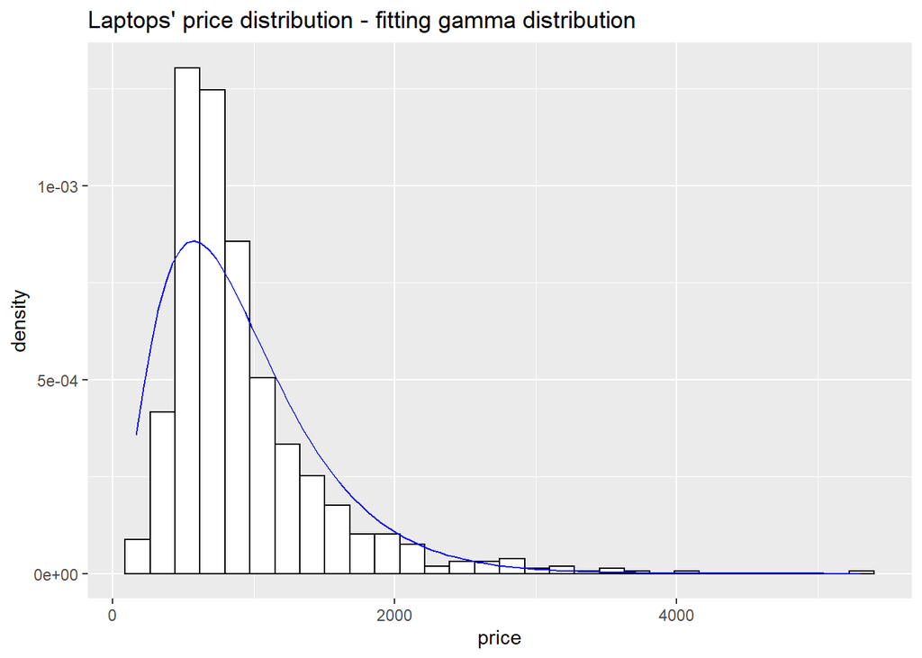

```r
### Estimating gamma parameters
scale_gam <- var(df$price)/mean(df$price) # mean(df$price) = E(X) = shape*scale
shape_gam <- mean(df$price)/scale_gam # var(df$price) = Var(X) = shape*scale^2

ggplot(df, aes(x=price)) +
    geom_histogram(aes(y=..density..), bins=30, color = "black", fill="white")  + labs(title="Laptops' price distribution - fitting gamma distribution") + stat_function(fun=dgamma, args=list(shape=shape_gam, scale=scale_gam), col="blue")
```

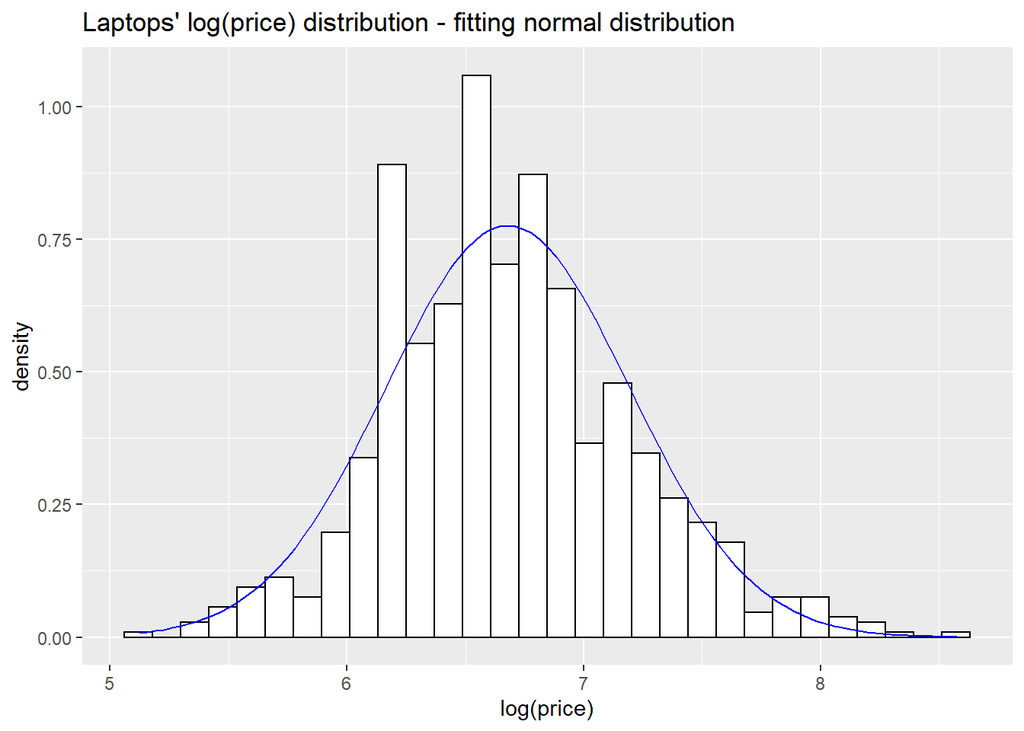

```r
ggplot(df, aes(x=log(price))) +
    geom_histogram(aes(y=..density..), bins=30, color = "black", fill="white")  + labs(title="Laptops' log(price) distribution - fitting normal distribution") + stat_function(fun=dnorm, args=list(mean=mean(log(df$price)), sd=sd(log(df$price))), col="blue")
```

If we transform the price with the logarithmic function, the distribution gets closer to a normal. I will use the log transformation quite often in this study, specially to compare prices for different categories of a variable.

The cheapest laptop costs 168€ and the most expensive has a selling price of 5304€. Half the laptops’ cost is between 545€ and 1069€, and the median price is around 762€.

# 5 Categorical attributes analysis

**Tables**

```r
attach(df)
table(brand); table(hdd); table(ssd); table(graphic_card_gb); table(ram_gb); table(processor_brand); table(weight); table(msoffice); table(touchscreen); table(warranty)
```

```
## brand
##   ASUS   DELL Lenovo     HP  Other   acer    MSI  APPLE
##    254    154    148    142     60     58     52     28
```

```
## hdd
##  No Yes
## 729 167
```

```
## ssd
##    0  256  512 1024
##  152  214  416  114
```

```
## graphic_card_gb
##   0   2   4   6
## 631  69 138  58
```

```
## ram_gb
##   4   8  16
## 102 543 251
```

```
## processor_brand
## Intel   AMD Apple Other
##   645   208    24    19
```

```
## weight
## ThinNlight     Casual     Gaming
##        291        566         39
```

```
## msoffice
##  No Yes
## 606 290
```

```
## touchscreen
##  No Yes
## 793 103
```

```
## warranty
##  No Yes
## 332 564
```

```r
detach(df)
```

**Bar plots**

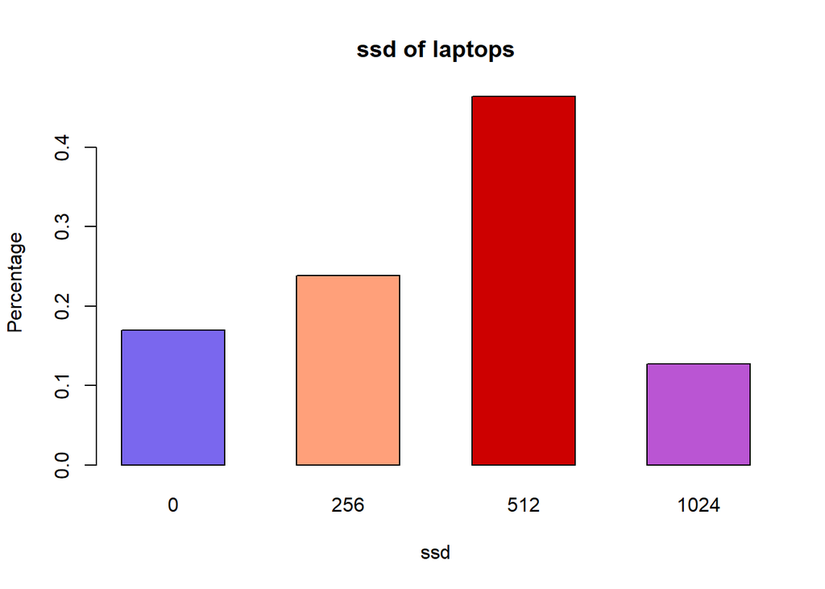

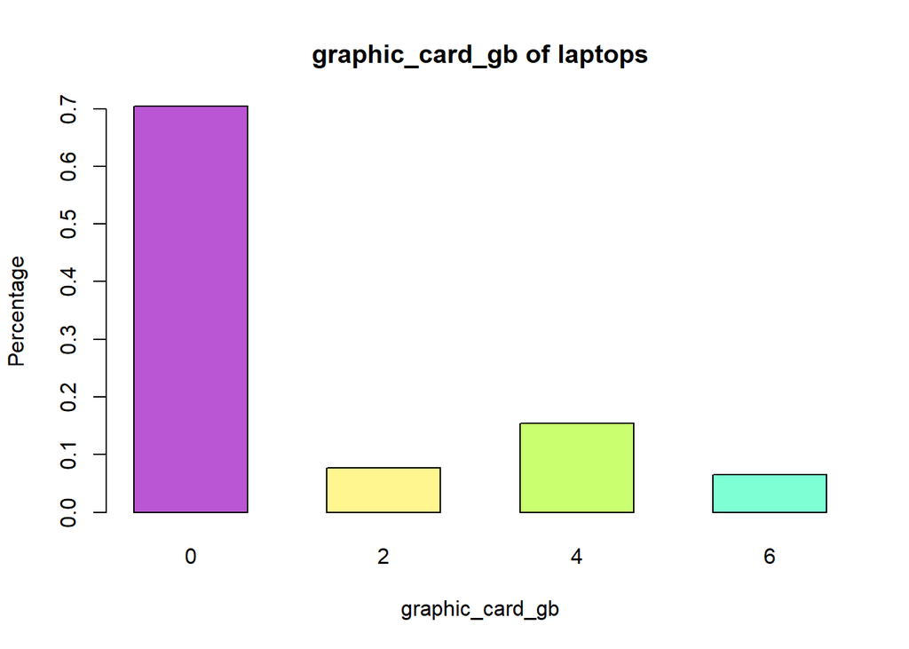

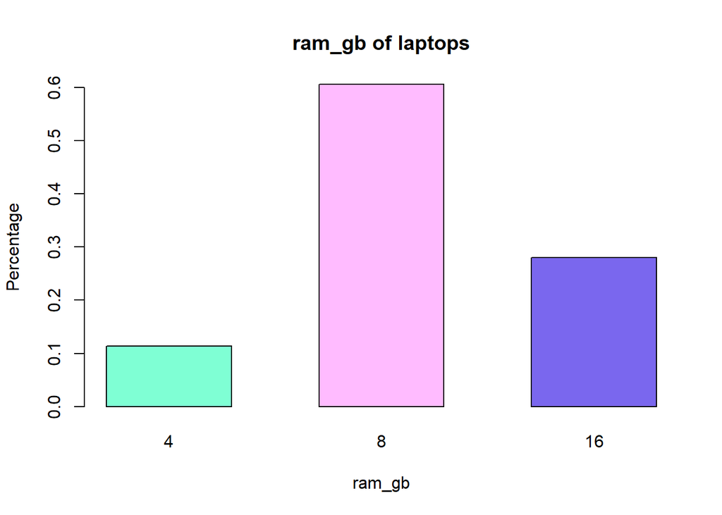

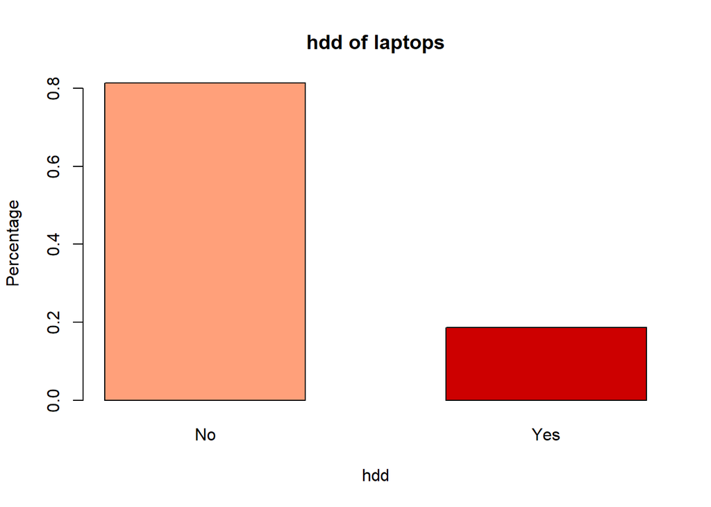

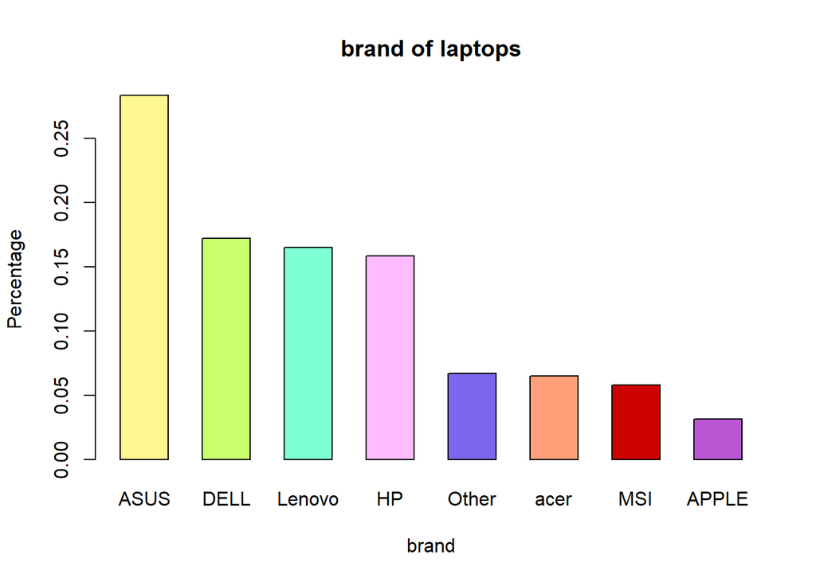

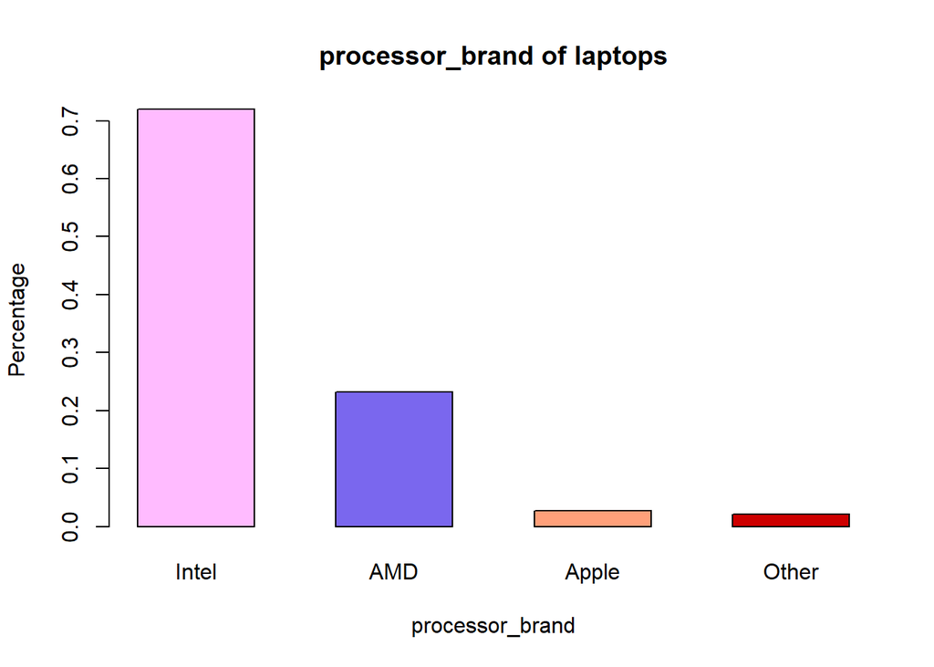

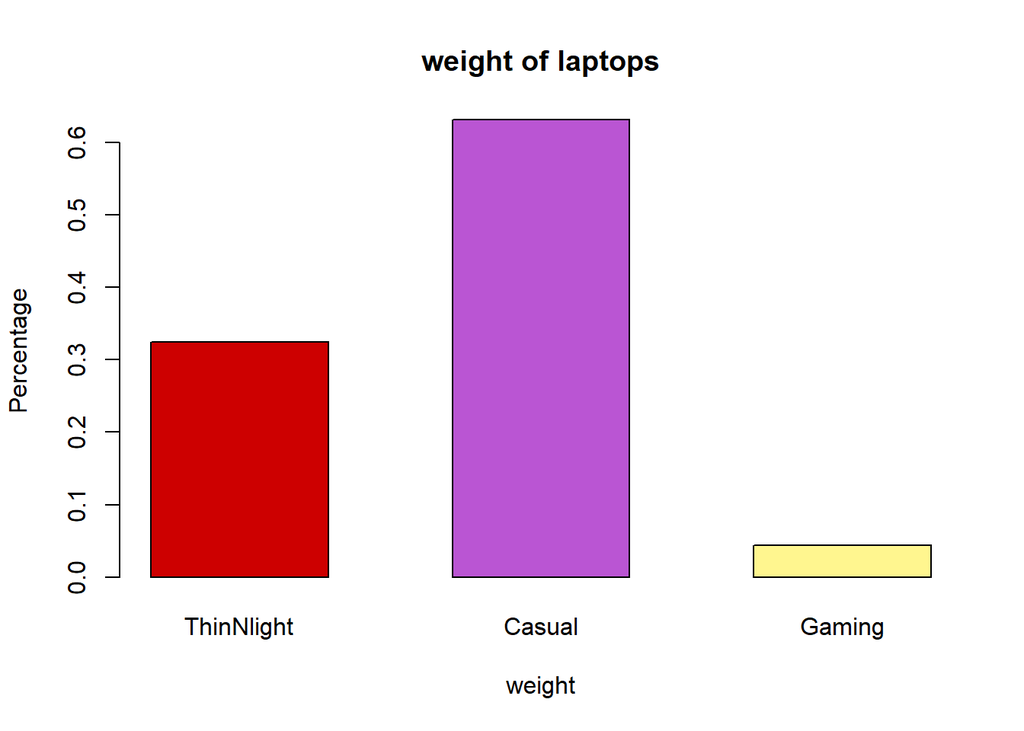

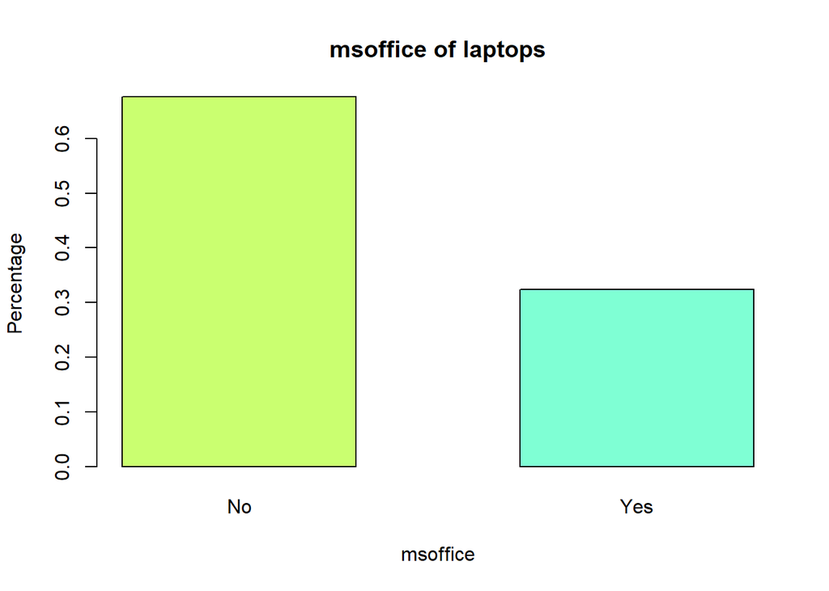

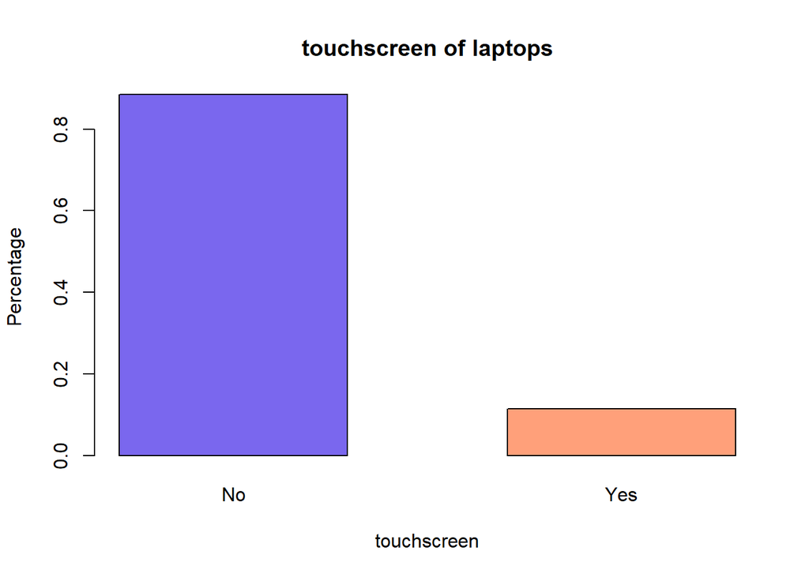

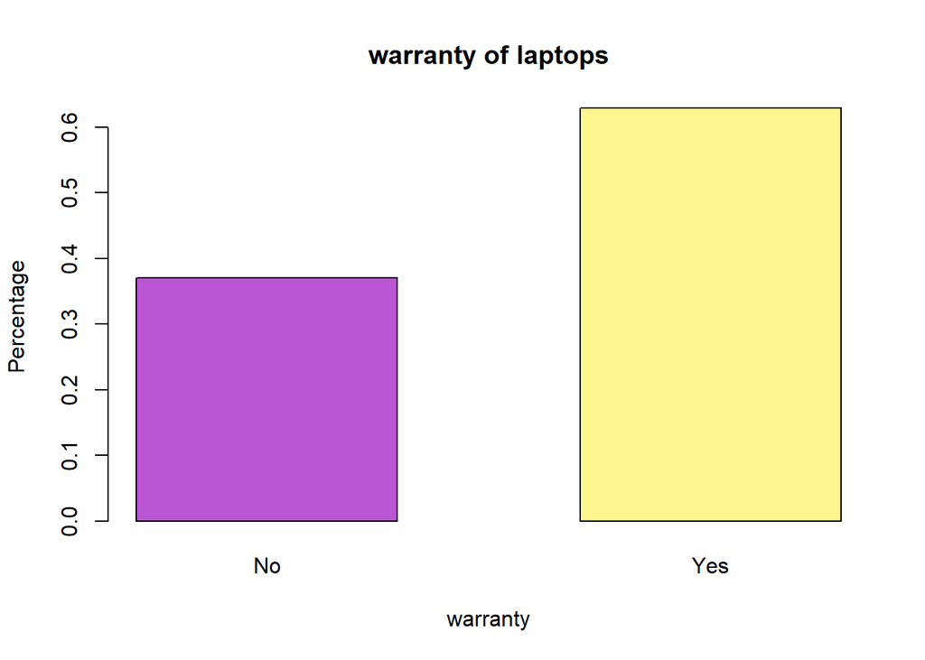

```r
ch_var <- c("ssd", "graphic_card_gb", "ram_gb", "hdd", "brand", "processor_brand", "weight", "msoffice", "touchscreen",
             "warranty")

colrs <- c("slateblue2", "lightsalmon", "red3", "mediumorchid", "khaki1", "darkolivegreen1", "aquamarine", "plum1")

for(i in 1:length(ch_var)){

  counts <- table(df[, ch_var[i]])
  barplot(prop.table(counts), col=colrs,
          main= paste(ch_var[i], "of laptops"), xlab = ch_var[i], ylab = "Percentage", space=0.7)
  colrs <- colrs[c(4:length(colrs), 1:3)] # rotating colors
}
```

# 6 Bivariate analysis

## 6.1 Price vs predictor features

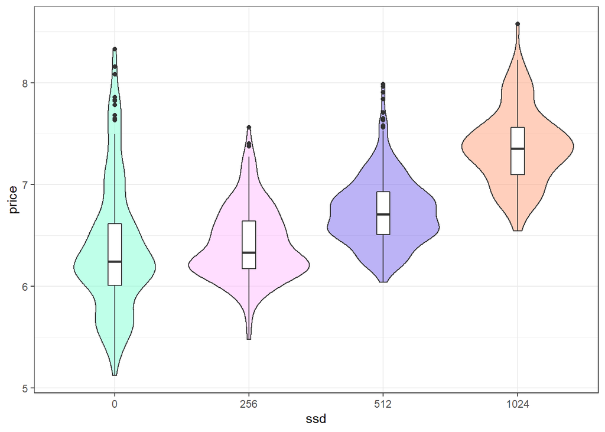

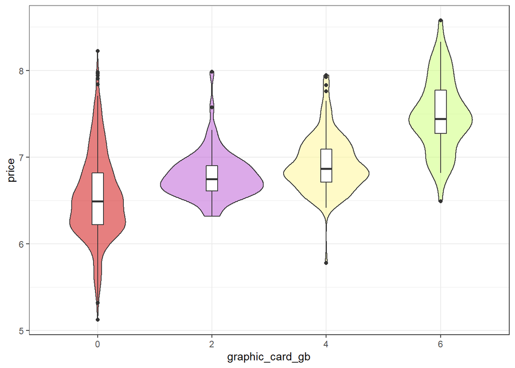

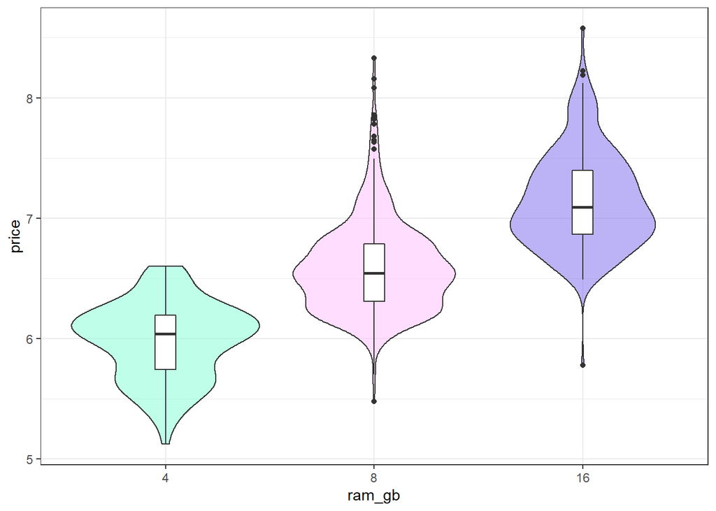

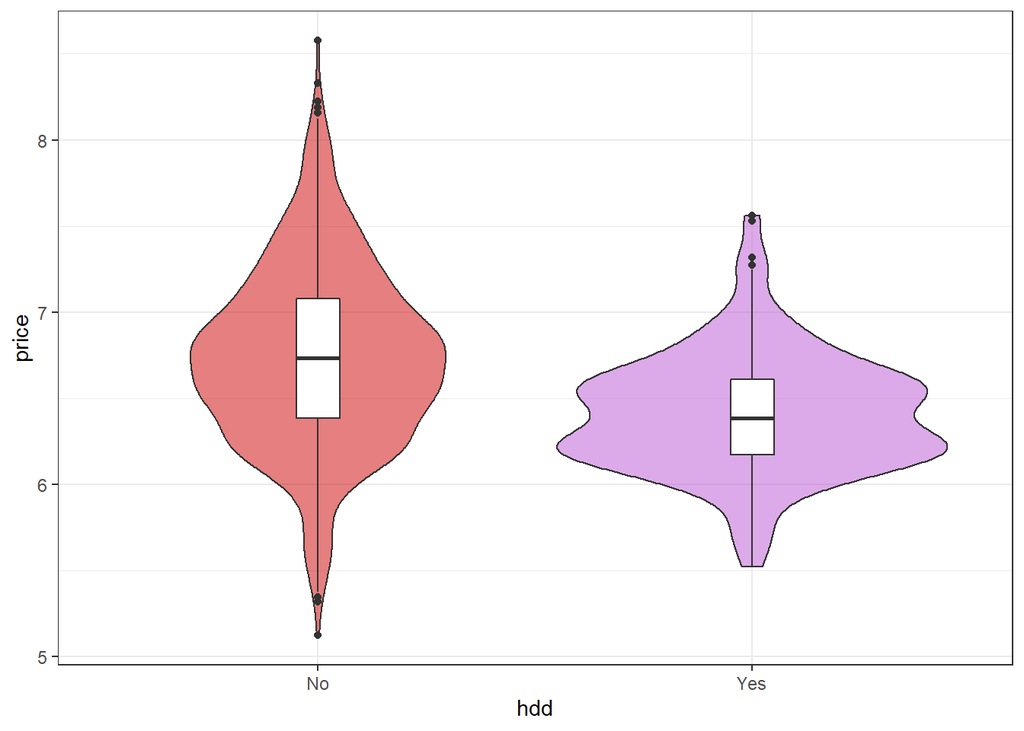

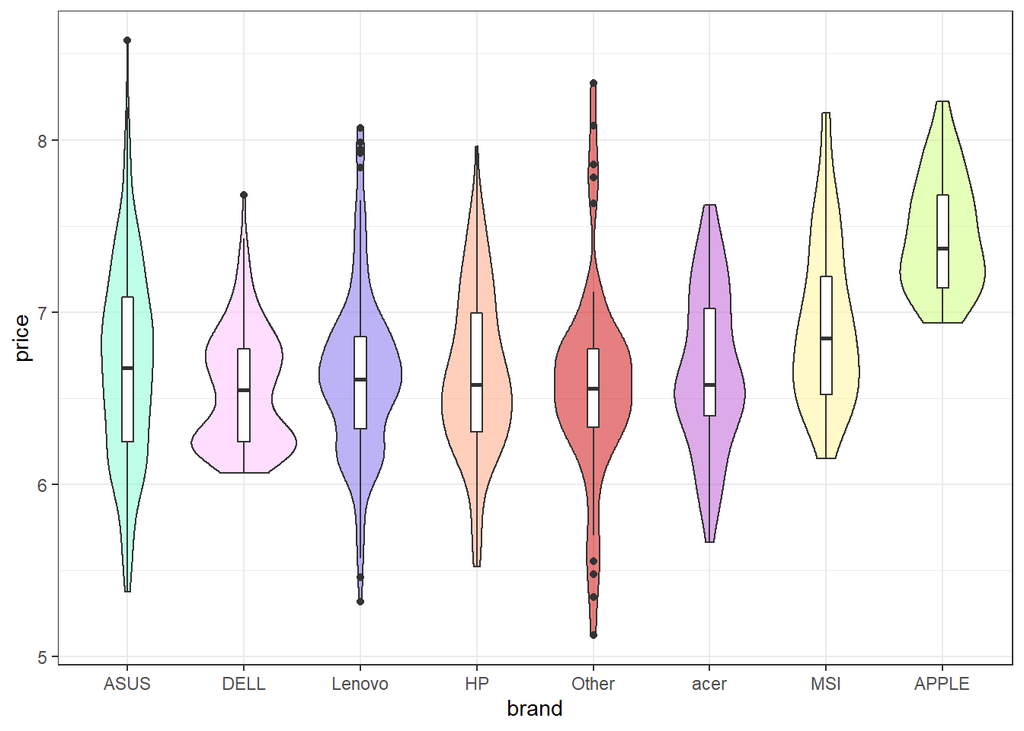

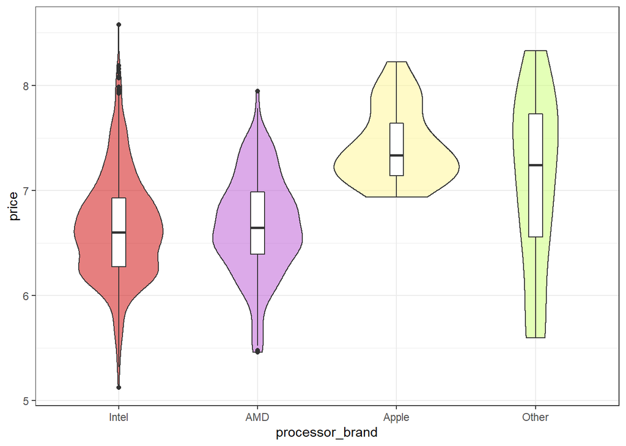

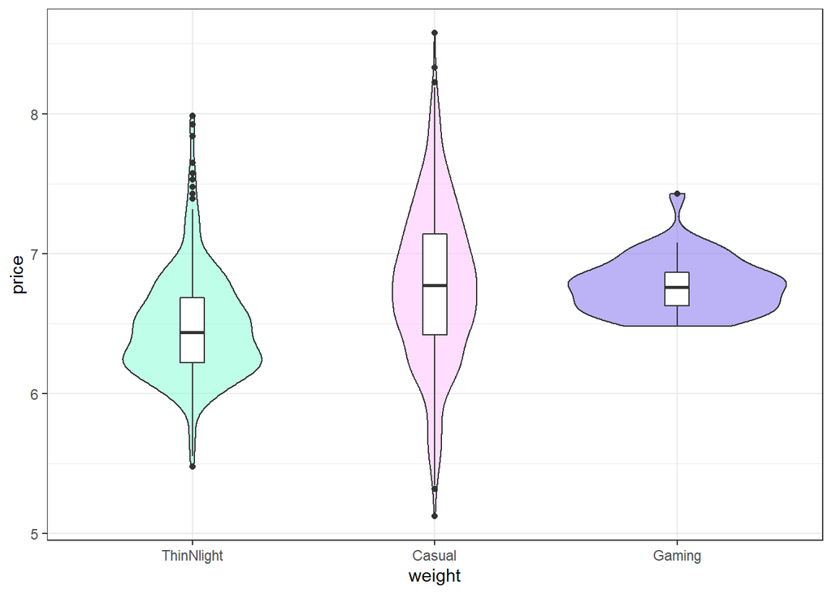

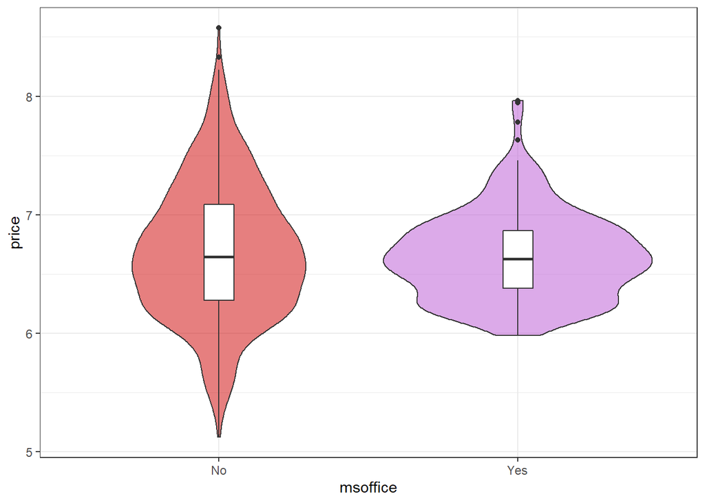

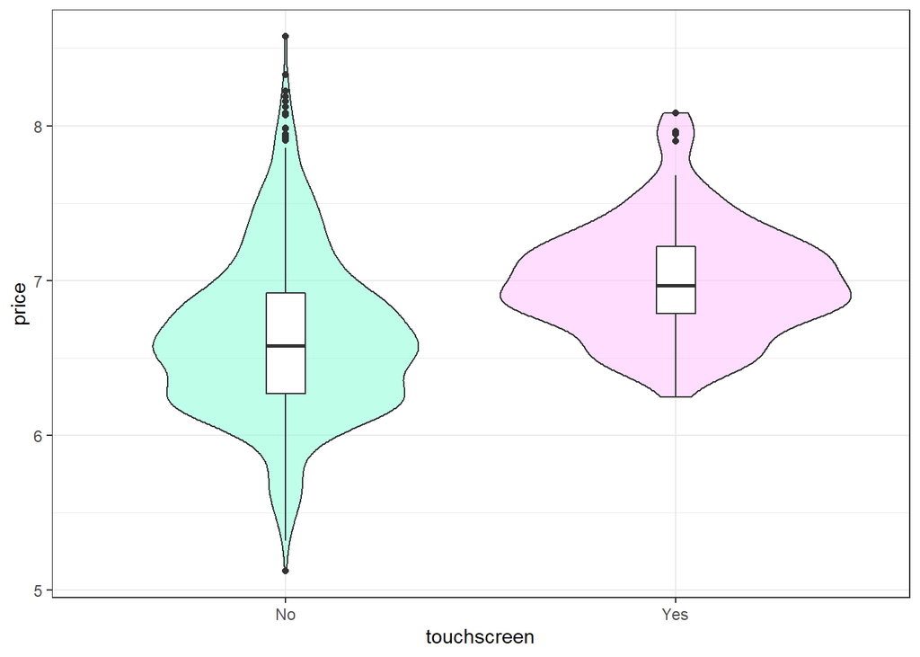

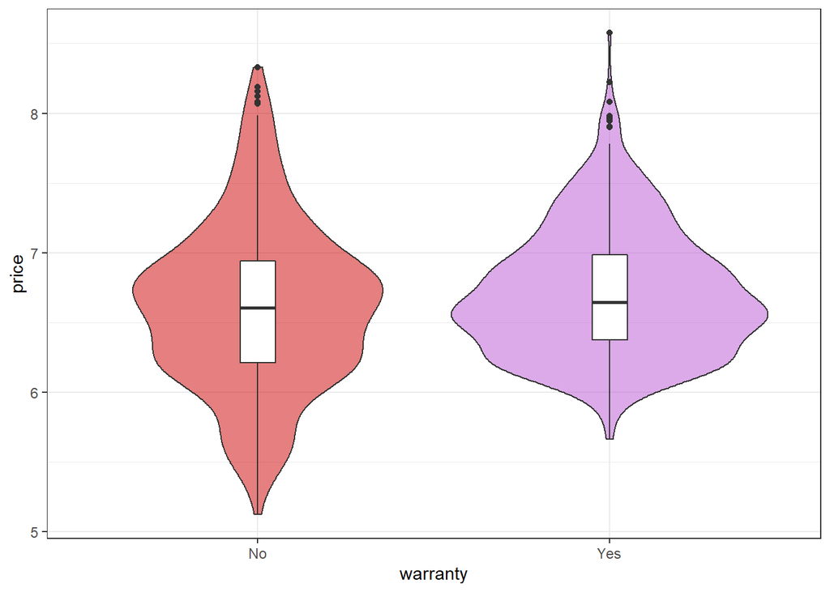

```r
for(i in 1:length(ch_var)){
  xvar <- df[, ch_var[i]]

  g <- ggplot(df, aes(x=factor(xvar), y=log(price), fill=factor(xvar))) + geom_violin(alpha=0.5) + labs(y="price", x=ch_var[i]) + geom_boxplot(width=0.1, fill="white") + scale_fill_manual(values=colrs) + theme_bw() + theme(legend.position="none")
  print(g)

  colrs <- colrs[c(5:length(colrs), 1:4)] # rotating colors
}
```

More GB in the SSD means higher price for the laptop. Same happens for the graphic card and ram memories. On the other hand, having an HDD storage leads to lower price on the laptop. I will study if the laptops with an HDD are those that don’t have an SSD.

## 6.2 Exploring storage (HDD & SSD)

They are the two most used storage devices for computers nowadays. The initials stand for Hard Drive Disk or Solid State Drive.

As we have seen in the previous graphs, that cost on laptops gets higher with bigger storage disks.

It is known that SSD have a better performance than HDD, but they are more expensive.

Let’s check if that is true, by grouping the 2 storage attributes into 1 variable called “storage” with all the possible combinations.

```r
df <- transform(df, storage=paste(hdd,ssd))
df$storage <- factor(df$storage, levels=c("No 0", "Yes 0", "No 256", "Yes 256", "No 512", "Yes 512", "No 1024"),
                     labels=c("none", "1024hdd", "256ssd", "1024hdd_256ssd", "512ssd", "1024hdd_512ssd", "1024ssd"))
table(df$storage)
```

```
##
##           none        1024hdd         256ssd 1024hdd_256ssd         512ssd
##             64             88            140             74            411
## 1024hdd_512ssd        1024ssd
##              5            114
```

There are 64 laptops without any storage. It must be treated as NA since they must have a storage disk (missing information)

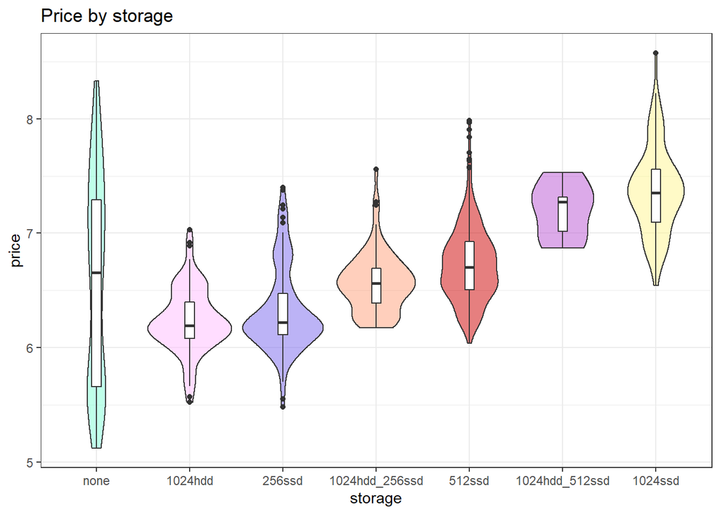

```r
ggplot(df, aes(x=storage, y=log(price), fill=storage)) + geom_violin(alpha=0.5) + labs(y="price", x="storage", title="Price by storage") + geom_boxplot(width=0.1, fill="white") + scale_fill_manual(values=colrs) + theme_bw() + theme(legend.position="none")
```

If we compare 1024GB hdd (2nd group) with 1024GB ssd (last group) laptops, we clearly see that ssd is way more expensive.

Looks like the price for 256GB ssd is equivalent to the cost of a 1024GB hdd storage.

### 6.2.1 Grouping storage

To be sure of this, we can do a statistical test for a measure of central tendency between 2 independent samples.

T-test if they the price is normally distributed. Otherwise we can do Mann-Whitney non-parametric test.

```r
df_low <- df %>%
  filter(storage %in% c("1024hdd", "256ssd"))

wilcox.test(df_low$price  ~ fct_drop(df_low$storage, )) # Mann-Whitney U test for differences in price between 2 groups
```

```
##
##  Wilcoxon rank sum test with continuity correction
##
## data:  df_low$price by fct_drop(df_low$storage, )
## W = 5602, p-value = 0.2502
## alternative hypothesis: true location shift is not equal to 0
```

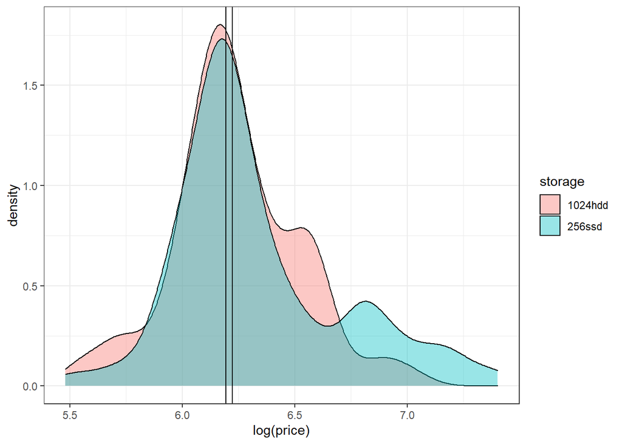

```r
med1 <- median(log(df_low[df_low$storage %in% "1024hdd", ]$price))
med2 <- median(log(df_low[df_low$storage %in% "256ssd", ]$price))

ggplot(df_low, aes(fill=storage, x=log(price))) + geom_density(alpha=0.4) + geom_vline(aes(xintercept=med1)) + geom_vline(aes(xintercept=med2)) + theme_bw()
```

We can consider that the first 2 groups have the same median price. The distribution also looks very similar.

I will name this group “Sufficient”.

```r
df_medium <- df[df$storage %in% c("1024hdd_256ssd", "512ssd"),]
wilcox.test(df_medium$price  ~ df_medium$storage)
```

```
##
##  Wilcoxon rank sum test with continuity correction
##
## data:  df_medium$price by df_medium$storage
## W = 10638, p-value = 3.845e-05
## alternative hypothesis: true location shift is not equal to 0
```

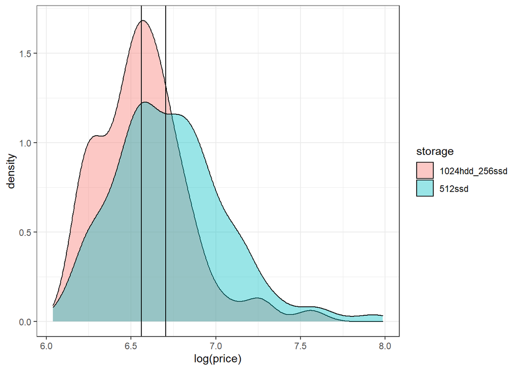

```r
med3 <- median(log(df_medium[df_medium$storage %in% "1024hdd_256ssd", ]$price))
med4 <- median(log(df_medium[df_medium$storage %in% "512ssd", ]$price))

ggplot(df_medium, aes(fill=storage, x=log(price))) + geom_density(alpha=0.4) + geom_vline(aes(xintercept=med3)) + geom_vline(aes(xintercept=med4)) + theme_bw()
```

```r
df_high <- df[df$storage %in% c("1024hdd_512ssd", "1024ssd"),]
wilcox.test(df_high$price  ~ df_high$storage)
```

```
##
##  Wilcoxon rank sum test with continuity correction
##
## data:  df_high$price by df_high$storage
## W = 208, p-value = 0.3109
## alternative hypothesis: true location shift is not equal to 0
```

```r
table(df$storage)[levels(df$storage) %in% c("1024hdd_512ssd", "1024ssd")]
```

```
##
## 1024hdd_512ssd        1024ssd
##              5            114
```

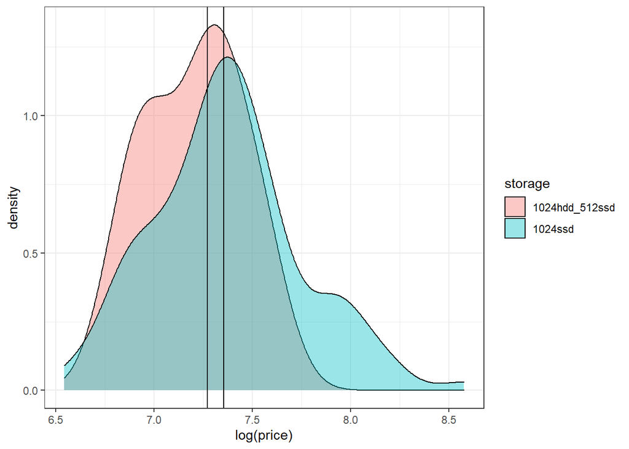

```r
med5 <- median(log(df_high[df_high$storage %in% "1024hdd_512ssd", ]$price))
med6 <- median(log(df_high[df_high$storage %in% "1024ssd", ]$price))

ggplot(df_high, aes(fill=storage, x=log(price))) + geom_density(alpha=0.4) + geom_vline(aes(xintercept=med5)) + geom_vline(aes(xintercept=med6)) + theme_bw()
```

These last two storage classes are somewhat similar. The top of the distribution for the price is close for each class, even though the 1024GB sdd has a tail on the right and the class 1024GB hdd + 512GB ssd has the tail on the left.

If we consider that the 2 classes are very imbalanced, makes sense to put the laptops from the less frequent class to the more frequent. I will rename this merged class to “Excellent”.

**Conclusion of the grouping:**

We can group 1024hdd with 256ssd and 1025hdd_512ssd with 1024ssd. The other categories left are “none”, 1024hdd_256ssd and 512ssd

So will we go from 7 categories (including NA) to only 5.

```r
df_gr <- df
df_gr$storage <- fct_collapse(df_gr$storage, Excellent = c("1024hdd_512ssd", "1024ssd"), "Very good" = "512ssd", Good = "1024hdd_256ssd", Sufficient = c("1024hdd", "256ssd"))
table(df_gr$storage)
```

```
##
##       none Sufficient       Good  Very good  Excellent
##         64        228         74        411        119
```

```r
# drop unnecessary and redundant columns
df_gr$hdd <- NULL
df_gr$ssd <- NULL
```

### 6.2.2 Filling NAs in storage

**Are the NA random or non random?**

As seen in the previous graphic with all the storage categories, the “none” storage laptops distribution for the price didn’t seem to be similar to the distribution of any specific class, so I believe they are random (the NA’s are not from just one class or only a few).

Let’s check if the price for this laptops is similar to all the other classes grouped into one.

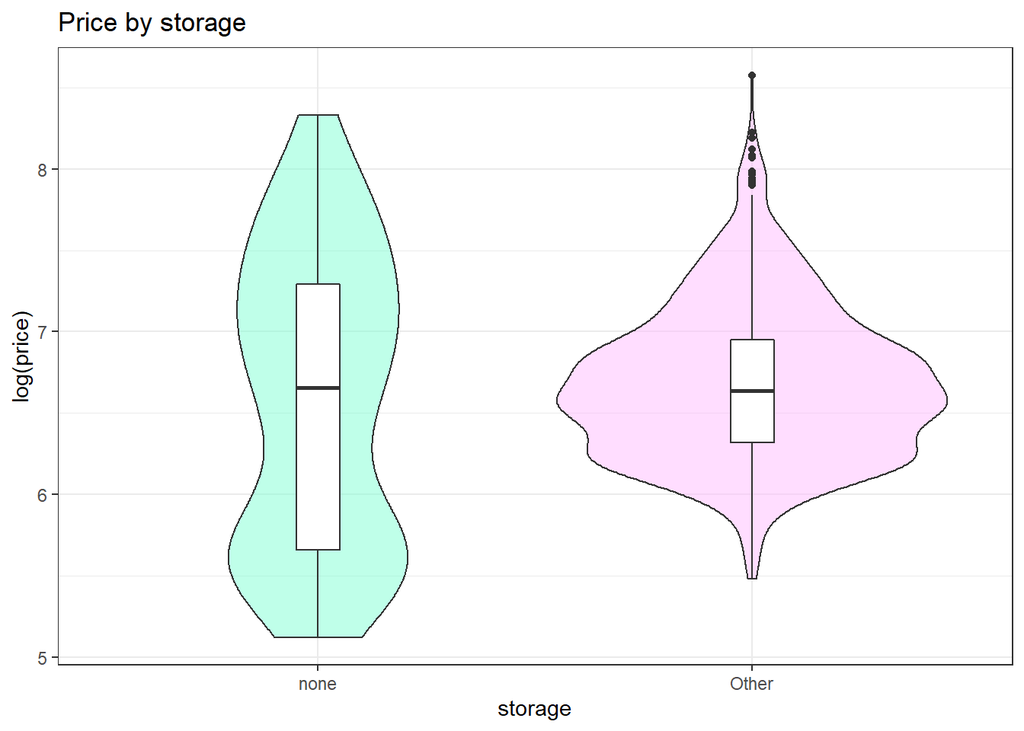

```r
ggplot(df_gr, aes(x=fct_other(storage, keep="none"), y=log(price), fill=fct_other(storage, keep="none"))) + geom_violin(alpha=0.5) + labs(y="log(price)", x="storage", title="Price by storage") + geom_boxplot(width=0.1, fill="white") + scale_fill_manual(values=colrs) + theme_bw() + theme(legend.position="none")
```

There seems to be more variance in the NAs. There are less laptops so it was to be expected.

The central tendency is very close for both cases. Nevertheless, the distribution of the NA’s has two local maximum points. They seem to be around a price of 245€ (exp(5.5)) or 1096€ (exp(7)) in contrast with the other laptops which tend to have a price of about exp(6.5) = 665€.

I think the best way to fill the NA’s is to classify each of these laptops into the class that has a nearer median.

So I just need to have all 4 medians calculated and then fill each NA laptop’s price with the nearest median value.

Another possibility would be doing K-Nearest Neighbors.

**Filling the NA’s**

```r
df_NA <- df_gr[df_gr$storage == "none", c("price", "storage")]
price_NA <- log(df_NA$price)

med01 <- median(log(df_gr[df_gr$storage == "Sufficient", ]$price))
med02 <- median(log(df_gr[df_gr$storage == "Good", ]$price))
med03 <- median(log(df_gr[df_gr$storage == "Very good", ]$price))
med04 <- median(log(df_gr[df_gr$storage == "Excellent", ]$price))

similar <- c()
for(i in 1:length(price_NA)){
  v <- c(abs(price_NA[i] - med01), abs(price_NA[i] - med02),
         abs(price_NA[i] - med03), abs(price_NA[i] - med04))
  similar[i] <- which.min(v)
}
similar <- factor(similar, labels=c("Sufficient", "Good", "Very good", "Excellent"))
table(similar)
```

```
## similar
## Sufficient       Good  Very good  Excellent
##         27          5          7         25
```

Most laptops with NA on storage will be classified as “Sufficient” or “Excellent”.

```r
# Before
table(df_no_fill$storage)
```

```
##
##       none Sufficient       Good  Very good  Excellent
##         64        228         74        411        119
```

```r
# laptops[rownames(laptops) %in% rownames(df_NA) ,] # You can check the real storage with the brand and model
df_gr[rownames(df_gr) %in% rownames(df_NA),]$storage <- similar # fills the NA
df_gr$storage <- fct_drop(df_gr$storage) # remove "none" category
# After
table(df_gr$storage)
```

```
##
## Sufficient       Good  Very good  Excellent
##        255         79        418        144
```

## 6.3 Exploring brands

It would be interesting to reduce the amount of categories for this attributes for the later linear regression models. Especially those groups with very few instances. This is not really necessary when doing random forest.

Also, we want to group the “Other” category with the most similar one.

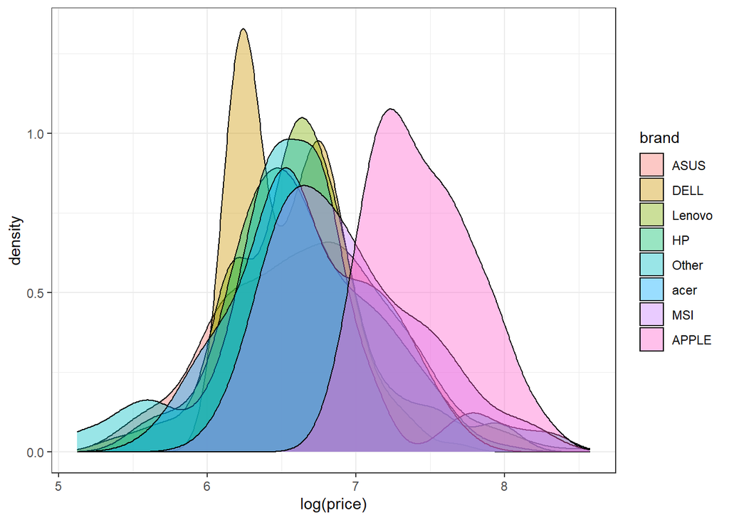

```r
ggplot(df_gr, aes(fill=brand, x=log(price))) + geom_density(alpha=0.4) + theme_bw()
```

APPLE and DELL are definitely not groupable with any other class.

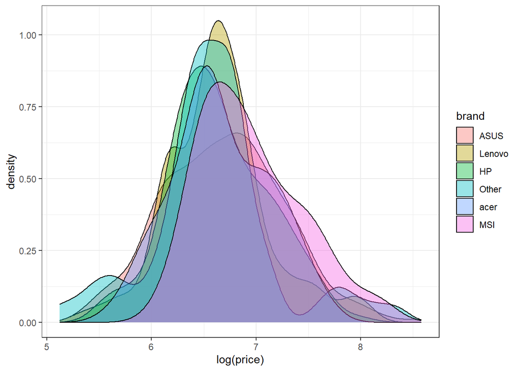

```r
df_brand <- df_gr[!df_gr$brand %in% c("APPLE", "DELL"),]
ggplot(df_brand, aes(fill=brand, x=log(price))) + geom_density(alpha=0.4) + theme_bw()
```

```r
# Kruskal Wallis test for 1 num dep. and multiple groups
kruskal.test(df_brand$price ~ df_brand$brand)
```

```
##
##  Kruskal-Wallis rank sum test
##
## data:  df_brand$price by df_brand$brand
## Kruskal-Wallis chi-squared = 16.095, df = 5, p-value = 0.006579
```

Kruskal Wallis test indicates that there is some difference between selling prices for the brands (at least 1 brand has different price that all the other ones).

### 6.3.1 Grouping brands

First I’ll try to group the “Other” category with another one

```r
shapiro.test(log(df_brand[df_brand$brand =="Other", ]$price))
```

```
##
##  Shapiro-Wilk normality test
##
## data:  log(df_brand[df_brand$brand == "Other", ]$price)
## W = 0.93589, p-value = 0.003562
```

Other laptops’s price is not normally distributed. Not even with the logarithmic transformation.

We need to do non-parametric test for comparing 2 median with 2 classes (Wilcoxon test).

```r
# table(df_brand$brand)[3:6] # not balanced classes
df_brand1 <- df_brand[df_brand$brand %in% c("Other", "acer"),]
# Wilcoxon test for Other and Acer laptop prices
wilcox.test(df_brand1$price  ~ df_brand1$brand)
```

```
##
##  Wilcoxon rank sum test with continuity correction
##
## data:  df_brand1$price by df_brand1$brand
## W = 1568.5, p-value = 0.3572
## alternative hypothesis: true location shift is not equal to 0
```

```r
df_brand2 <- df_brand[df_brand$brand %in% c("Other", "HP"),]
# Wilcoxon test for Other and HP laptop prices
wilcox.test(df_brand2$price  ~ df_brand2$brand)
```

```
##
##  Wilcoxon rank sum test with continuity correction
##
## data:  df_brand2$price by df_brand2$brand
## W = 4556.5, p-value = 0.4356
## alternative hypothesis: true location shift is not equal to 0
```

```r
df_brand3 <- df_brand[df_brand$brand %in% c("Other", "Lenovo"),]
# Wilcoxon test for Other and Lenovo laptop prices
wilcox.test(df_brand3$price  ~ df_brand3$brand)
```

```
##
##  Wilcoxon rank sum test with continuity correction
##
## data:  df_brand3$price by df_brand3$brand
## W = 4758.5, p-value = 0.4187
## alternative hypothesis: true location shift is not equal to 0
```

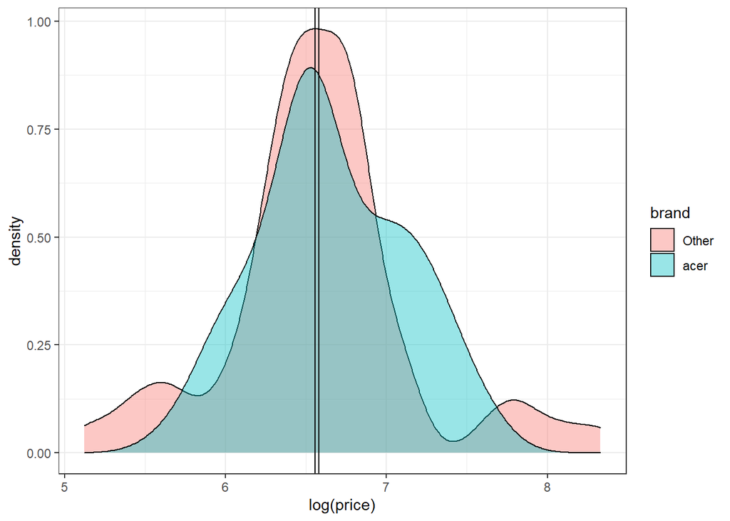

```r
med_br1 <- median(log(df_brand1[df_brand1$brand %in% "Other", ]$price))

med_br2 <- median(log(df_brand1[df_brand1$brand %in% "acer", ]$price))
ggplot(df_brand1, aes(fill=brand, x=log(price))) + geom_density(alpha=0.4) + geom_vline(aes(xintercept=med_br1)) + geom_vline(aes(xintercept=med_br2)) + theme_bw()
```

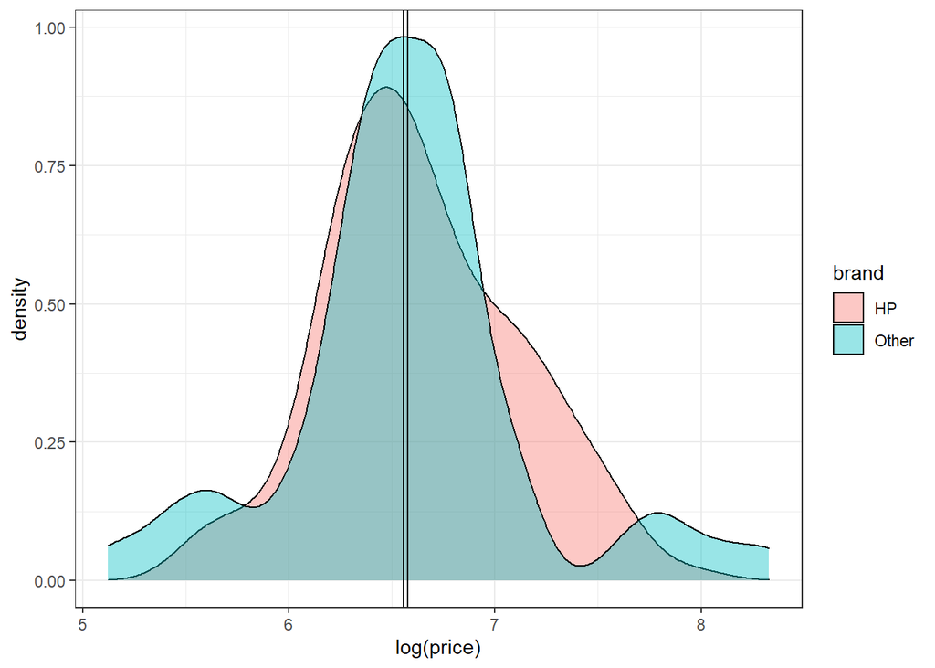

```r
med_br3 <- median(log(df_brand2[df_brand2$brand %in% "HP", ]$price))
ggplot(df_brand2, aes(fill=brand, x=log(price))) + geom_density(alpha=0.4) + geom_vline(aes(xintercept=med_br1)) + geom_vline(aes(xintercept=med_br3)) + theme_bw()
```